# Proyectos en Open Data

## API Opendata

[`opendata.somenergia.coop`](https://opendata.somenergia.coop)

**Datos anominizados por agregación**

Primera versión pública

Métricas: Socias y contratos

Detalle geográfico hasta municipio

Secuencia histórica mensual

## Posibles proyectos

**Explotar los datos:**

Aplicaciones de análisis

Visualizaciones, interactivos, mapas…

**Ayudarnos a hacerla mas potente:**

Nuevas métricas

Referencias relativas. Eventos

Mejorar el front-end

## Herramientas de Análisis

Cuadros de control

Mineria temporal y geográfica

Correlacionar con eventos

Animaciones, interactivos…

Widgets insertables en el blog

## Visualización

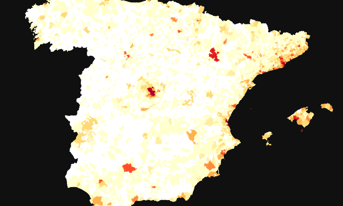

Mapas color

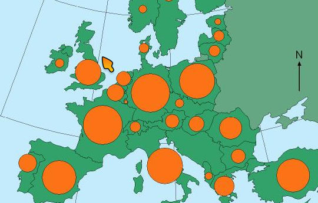

Mapas burbujas

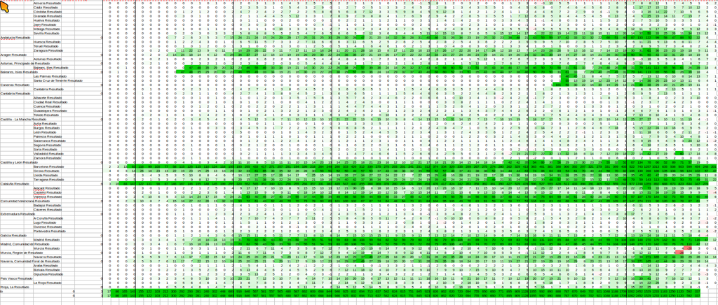

Tablas

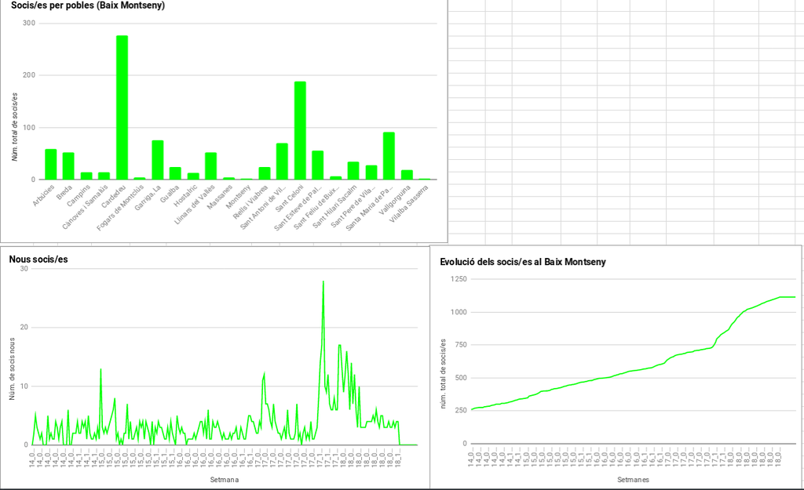

Gráficas

[figure not shown]

Tree Map

## Nuevas métricas

Cantidades que podamos agregar a nivel de municipio.

Muchas requieren acceso al ERP y las tenemos que hacer en Girona

¿Cúales interesa implementar para vuestras aplicaciones?

Otras no y las podeis aportar vosotros mismos.

## Métricas de comercialización

Mejorar socias y contratos

Consumo agregado

Modificaciones de contrato

Reclamaciones

## Métricas de producción

**Plantas de generación**

Potencia / Producción

**Autoproducción**

Instalaciones / Potencia / Energía

## Nuevos filtros

**Atajos para peticiones frecuentes con muchos municipios o províncias**

Grupos locales

Coordinadoras territoriales

Comarcas. Super regiones.

Dominios lingüísticos

## Eventos

**Situarlos en el tiempo para contrastar su efecto en las métricas.**

Grupos locales: Charlas, ferias, stands…

Apariciones en los medios

Campañas de Som. Notícias del sector

## Referencias relativas

**Relativizan las métricas a las características de cada zona.**

Son datos públicos, cualquiera puede integrar

Población, superficie (INE, los tenemos)

Puntos de suministro, demanda (REE, CNMC)

Actividad económica (PIB, Número de empresas…)

## Mejoras Front-end

**Permite construir las queries de forma gráfica**

`github:som-energia/webforms-mithril`

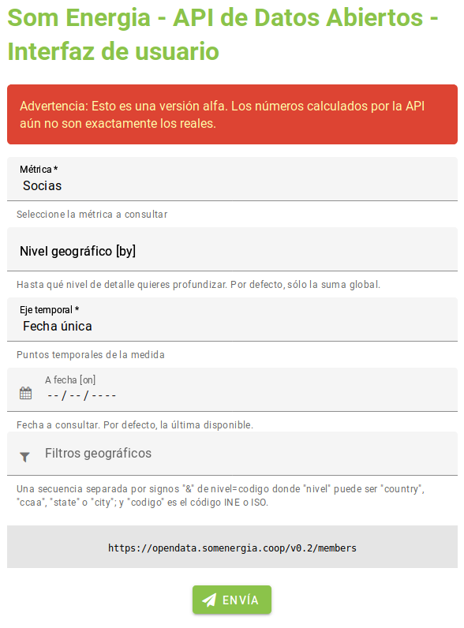

Editor de filtros

Mejorar la tabla

Integrar nuevas visualizaciones

Descarga en diferentes formatos

Generar widgets para el blog

## Referencias

[API Open Data](http://github.com/som-energia/somenergia-api)

[Front End Open Data](http://github.com/som-energia/webforms-mithril)

[SomMaps (HackaSom 2017)](http://github.com/som-labs/sommaps)

[Cuadro de control de socios, Baix Montseny](https://docs.google.com/a/somenergia.coop/spreadsheets/d/1Kb9USX6lmZ9Yq5AMVaVwpRQEvoJo-FNbHznoIMeF3gk%7D)

[Discusion sobre mapas en la Plataforma](https://plataforma.somenergia.coop/discussion/view/153870/som-maps)